# Happiness Index Report Analysis

Happiness Index and Population Well-being Alignment Exploration

Authors

Nanmanat Disayakamonpan

Leona Hasani

Leona Hoxha

Published

December 21, 2023

Abstract

Our report delves into the Happiness Index Data Set, unraveling the multifaceted elements that contribute to elevated happiness scores globally. Motivated by the overarching question of primary happiness influencers, we scrutinize indicators like GDP, social support, freedom, positive affect, and life expectancy. Venturing beyond, we intertwine the Happiness Index with the European Social Survey, unveiling a nuanced yet reliable alignment of cultural, economic, and social features with respondents’ happiness levels. This connection, underscored by a low standard deviation, portrays a complex but consistent relationship between official happiness indices and subjective well-being across Europe.

# Introduction

In our perspective, the pursuit of a better quality of life encompasses a desire for a stable economy, a supportive society, and personal freedom. With these aspirations in mind, our analysis delves into the Happiness Index Data Set, seeking to uncover the intricate factors that contribute to higher happiness scores in regions and countries worldwide.

Our research is motivated by a fundamental question: **What are the primary factors that influence happiness?** By leveraging the wealth of information in the happiness index data set, we aim to explore and dissect the key elements that play a pivotal role in shaping the overall well-being of individuals and societies.

Moreover, we embark on a journey to determine the predictability of happiness scores. **Can the happiness score be forecasted based on the indicators within the happiness index data set?** This question drives our exploration into the potential predictive power of the data set, offering insights into the dynamics of happiness over time.

Lastly, our investigation extends beyond the data set itself to scrutinize **the alignment of cultural, economic, and social features with the directional patterns of happiness observed in the European Social Survey Data Set.** This comparative analysis seeks to unravel connections and disparities, providing a holistic understanding of how various aspects contribute to the happiness landscape.

# Data

In this report, we use three data sets and get the data from the following resources:

1. **happyindex**: The Happiness Index Data Set

The data set **happyindex** is from **https://worldhappiness.report/ed/2023/#appendices-and-data**

- **Variable Description**
  - *life_ladder*
    - Happiness score or subjective well-being (SWB): The survey’s measure of SWB is the national average response to the question of life evaluations: *“Please imagine a ladder, with steps numbered from 0 at the bottom to 10 at the top”*. The top of the ladder represents the best possible life for you, and the bottom of the ladder represents the worst possible life for you. “On which step of the ladder would you say you personally feel you stand at this time?”
  - *log_GDP*
    - The statistics of GDP per capita (variable name GDP) in purchasing power parity (PPP) at constant 2017 international dollar prices are from World Development Indicators
  - *soc_support*
    - Social support is the national average of the binary responses (either 0 or 1) to the question “If you were in trouble, do you have relatives or friends you can count on to help you whenever you need them, or not?”
  - *life_exp*
    - Healthy Life Expectancy (HLE). Healthy life expectancies at birth are based on the data extracted from the World Health Organization’s (WHO) Global Health Observatory data repository.
  - *freedom*
    - Freedom to make life choices is the national average of responses to the question “Are you satisfied or dissatisfied with your freedom to choose what you do with your life?”
  - *generosity*
    - Generosity is the response to the question “Have you donated money to a charity in the past month?”. It is a clear marker for a sense of positive community engagement and a central way that humans connect with each other.
  - *corruption*
    - Corruption Perception: The measure is the national average of the survey responses to two questions: “Is corruption widespread throughout the government or not” and “Is corruption widespread within businesses or not?” The overall perception is just the average of the two 0-or-1 responses.
  - *pos_affect*
    - Positive affect is defined as the average of three positive affect measures: laugh, enjoyment and doing interesting things. These measures are the responses to the following three questions, respectively: “Did you smile or laugh a lot yesterday?”, and “Did you experience the following feelings during A LOT OF THE DAY yesterday? How about Enjoyment?”, “Did you learn or do something interesting yesterday?”
  - *neg_affect*
    - Negative affect is defined as the average of three negative affect measures. They are worry, sadness and anger, respectively the responses to “Did you experience the following feelings during A LOT OF THE DAY yesterday? How about Worry?”, “Did you experience the following feelings during A LOT OF THE DAY yesterday? How about Sadness?”, and “Did you experience the following feelings during A LOT OF THE DAY yesterday? How about Anger?”
2. **WDI**: World Development Indicator Data Set

The data set **WDI** is from **https://databank.worldbank.org/source/world-development-indicators#**

In this data set, we exclusively utilize the ‘region’ variable to merge with the ‘happyindex’ data set.

3. **ess**: European Social Survey Round 10 and 10SC (ESS10 & ESS10SC) Data Set

The data set **ess** is from **https://ess.sikt.no/en/data-builder/?tab=round_country&seriesVersion=775&variables=2.0.42_43_67+5.12**

- **Variable Description**
  - *influence_pol*
    - The variable ‘influence_pol’ represents the extent to which individuals believe the political system allows them to have influence on politics, with a scale ranging from 1 denoting ‘Not at All’ to 5 signifying ‘a Great Deal’.
  - *say_pol*
    - The variable ‘say_pol’ represents the extent to which individuals believe the Political system allows people to have a say in what government does, with a scale ranging from 1 denoting ‘Not at All’ to 5 signifying ‘a Great Deal’.
  - *satis_demo*
    - The variable ‘satis_demo’ represents the extent to which individuals are satisfied with the way democracy works in their country, with a scale ranging from 0 denoting ‘Extremely Dissatisfied’ to 10 signifying ‘Extremely Satisfied’.
  - *satis_eco*
    - The variable ‘satis_eco’ represents the extent to which individuals are satisfied with the present state of economy in their country, with a scale ranging from 0 denoting ‘Extremely Dissatisfied’ to 10 signifying ‘Extremely Satisfied’.
  - *satis_life*
    - The variable ‘satis_life’ represents the extent to which individuals are satisfied with life as a whole, with a scale ranging from 0 denoting ‘Extremely Dissatisfied’ to 10 signifying ‘Extremely Satisfied’.
  - *donate*
    - The variable ‘donate’ measures the extent of people’ donations or overall involvement in a political party or pressure organization in the past 12 months, with a scale ranging from 1 denoting ‘Yes’ to 2 signifying ‘No’.
  - *safety*
    - The variable ‘safety’ represents the extent to how much individuals feel safe of walking alone in local area after dark, with a scale ranging from 1 denoting ‘Very Safe’ to 4 signifying ‘Very Unsafe’.
  - *how_happy*
    - The variable ‘how_happy’ represents the extent to which individuals are satisfied with life as a whole, with a scale ranging from 0 denoting ‘Extremely Unhappy’ to 10 signifying ‘Extremely Happy’.
  - *health*
    - The variable ‘health’ represents the subjective general health, with a scale ranging from 1 denoting ‘Very Good’ to 5 signifying ‘Very Bad’.
  - *psn_matters*
    - The variable ‘psn_matters’ represents to how many people or with whom you can discuss intimate and personal matters, with a scale ranging from 0 denoting ‘None’ to 6 signifying ‘10 or more’.
  - *soc_meet*
    - The variable ‘soc_meet’ represents the extent to how often you socially meet with friends, relatives or colleagues, with a scale ranging from 1 denoting ‘Never’ to 7 signifying ‘Every day’.
  - *house_inc*
    - The variable ‘house_inc’ represents the extent to how individuals are feeling about household’s income nowadays, with a scale ranging from 1 denoting ‘Living comfortably on present income’ to 4 signifying ‘Very difficult on present income’.

We are undertaking this research with the aim of understanding the aspirations of individuals who seek a happier and higher quality of life. Utilizing the happiness index data set, we would like to explore the data sets to unravel answers to the following questions:

**1. What are the primary factors influencing happiness?**

**2. Can the happiness score be forecasted based on the indicators in the happiness index data set?**

**3. Do the cultural, economic, and social features in the happiness index data set align with how happy respondents observed in the European Social Survey Data Set are?**

# Analysis

## The Map of Happy Index Score among Countries Over Time

The following map will show the evolution of overall Happiness Index scores among countries over time, shedding light on the dynamic trends and patterns contributing to understanding global happiness levels. The darker green color represents the higher happiness score and the lighter one indicates the lower happiness score.

```
150 codes from your data successfully matched countries in the map
6 codes from your data failed to match with a country code in the map
93 codes from the map weren't represented in your data
```

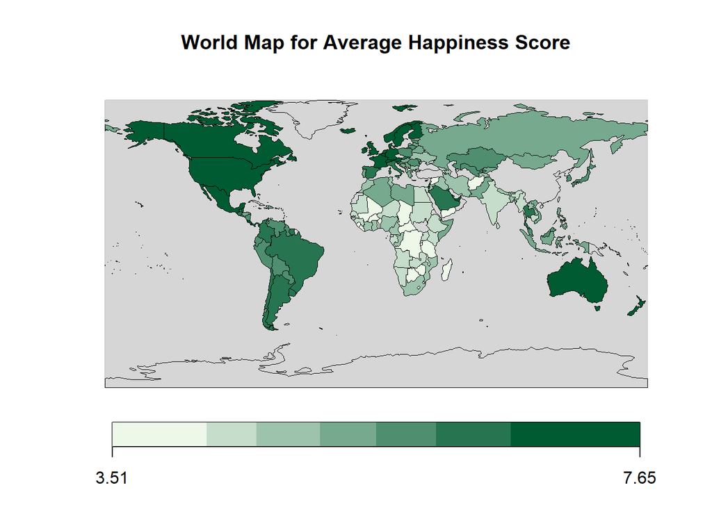

```r
#Creating a new dataframe with the name of each country and their respective average life ladder
suppressWarnings(
  {
average_life_ladder <- happyindex |>
  group_by(country) |>
  summarize(avg_life_ladder = mean(life_ladder, na.rm = TRUE))


d <- data.frame(
  country = average_life_ladder$country,
  value = average_life_ladder$avg_life_ladder
)

cols <- colorRampPalette(brewer.pal(7, "Greens"))(length(d))

n <- invisible(joinCountryData2Map(d, joinCode = "NAME", nameJoinColumn = "country"))



  mapCountryData(n, nameColumnToPlot = "value", mapTitle = "World Map for Average Happiness Score",
                 colourPalette = cols, oceanCol = "#CCCCCCCC", addLegend = TRUE,
                 aspect = 1.1, borderCol = "Black", lwd = 0.1)
 }
)
```

The map clearly illustrates a distinct distribution of happiness scores, with **higher ratings** concentrated in **North America, Central America, South America, Australia, and Europe**. In contrast, **lower scores** are prominently observed in **the continents of Africa and Asia**, highlighting regional disparities in global happiness levels.

## The Averages among Countries Over Time

### Happiness Score

This exploration focuses on unraveling the dynamics of the average life ladder among countries, offering valuable insights into which countries experienced higher happiness scores over time.

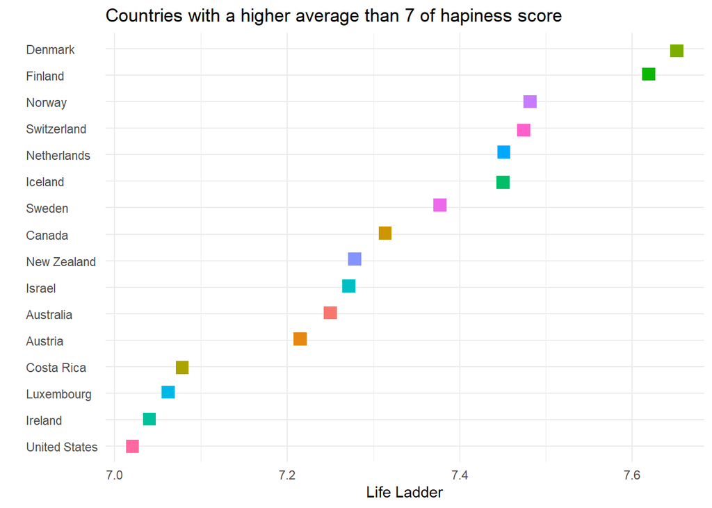

```r
#Filtering the average life ladder above 7
avg_lifeladder <- happyindex |>
  group_by(country) |>
  summarize(avg_lifeladder = mean(life_ladder, na.rm = TRUE)) |>
  filter(avg_lifeladder >= 7)

  ggplot(data = avg_lifeladder, aes(x = avg_lifeladder, y = reorder(country, avg_lifeladder), color = country)) +
  geom_point(position = position_jitterdodge(jitter.width = 0.2, dodge.width = 0.75), size = 4, shape = 15) +
  labs(title = "Countries with a higher average than 7 of hapiness score",
       x = "Life Ladder",
       y = "") +
  theme_minimal() +
  theme(axis.text.y = element_text(hjust = 0)) +
  theme(legend.position = "none")
```

As depicted in the graph, a notable observation emerges—**Europe** dominates *the top level of happiness scores*, with countries such as **Denmark, Finland, Norway, Switzerland, the Netherlands, Iceland, and Sweden** consistently securing positions among the top 10 nations with the highest well-being.

### GDP per Capita

This exploration focuses on unraveling the dynamics of the average GDP per Capita among countries, offering valuable insights into which countries have higher GDP per Capita over time.

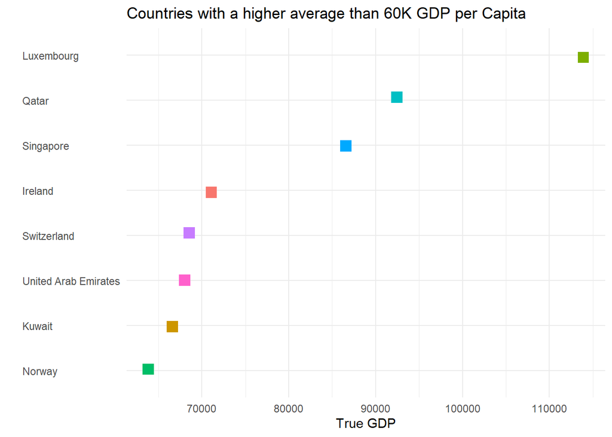

```r
happyindex$true_GDP <- exp(happyindex$log_GDP)

average_life_ladder2 <- happyindex |>
  group_by(country) |>
  summarize(avg_GDP = mean(true_GDP, na.rm = TRUE)) |>
  filter(avg_GDP > 60000)

  ggplot(data = average_life_ladder2, aes(x = avg_GDP, y = reorder(country, avg_GDP), color = country)) +
  geom_point(position = position_jitterdodge(jitter.width = 0.2, dodge.width = 0.75), size = 4, shape = 15) +
  labs(title = "Countries with a higher average than 60K GDP per Capita",
       x = "True GDP",
       y = "") +
  theme_minimal() +
  theme(axis.text.y = element_text(hjust = 0)) +
  theme(legend.position = "none")
```

Observing the graph, a striking pattern emerges: *while certain countries exhibit a consistent increase in GDP per capita over time, it becomes evident that economic prosperity alone does not guarantee a higher happiness score.* Illustratively, countries such as **Qatar, Singapore, the United Arab Emirates, and Kuwait** boast high GDP per capita, yet they do not secure positions in the top country lists for happiness scores, underscoring the nuanced relationship between economic wealth and overall well-being.

## Top countries who performed better in the Happy Index indicators, in 2020

### Happiness Score

This exploration delves into the distribution of happiness scores in the year 2020, providing insights into the varied levels of well-being experienced across different regions and countries during that specific period.

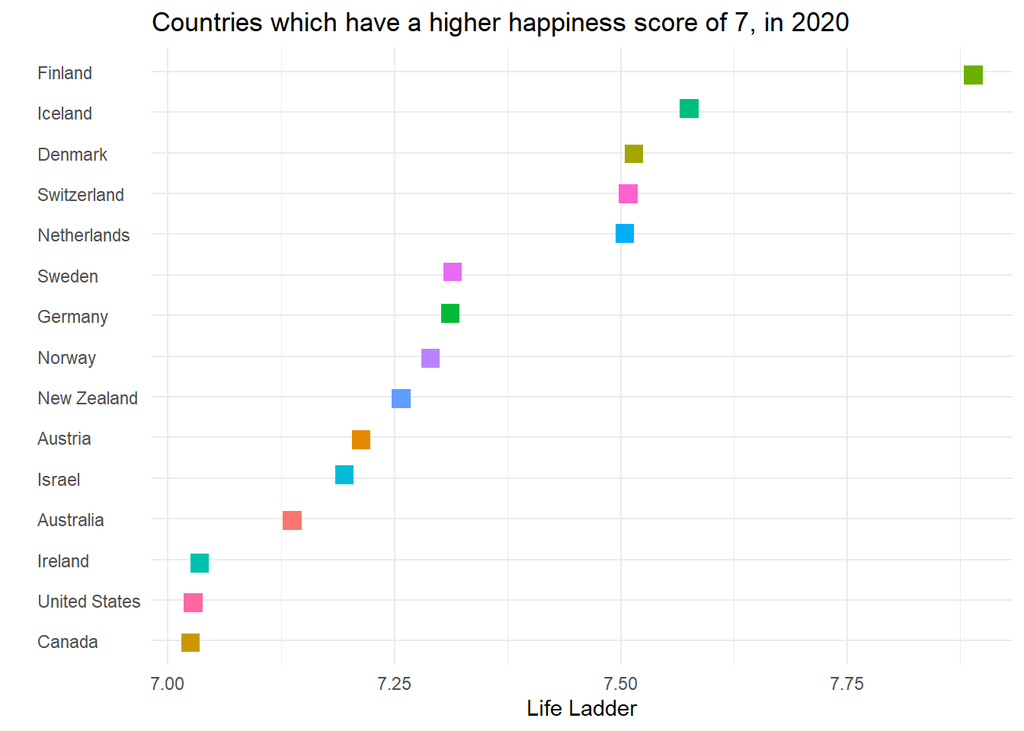

```r
happyindex2 <- happyindex |>
  filter(life_ladder >= 7, year == 2020)

#summary(happyindex)

ggplot(happyindex2, aes(x = life_ladder, y = reorder(country, life_ladder), color = country)) +
  geom_point(position = position_jitterdodge(jitter.width = 0.2, dodge.width = 0.75), size = 4, shape = 15) +
  labs(title = "Countries which have a higher happiness score of 7, in 2020",
       x = "Life Ladder",
       y = "") +
  theme_minimal() +
  theme(axis.text.y = element_text(hjust = 0)) +
  theme(legend.position = "none")
```

An evident trend persists as *European countries continue to dominate the highest positions in happiness scores in 2020*. Notable nations such as **Finland, Iceland, Denmark, Switzerland, the Netherlands, Sweden, Germany, and Norway** maintain their consistent presence at the forefront of well-being.

### GDP per Capita

This graph focuses on unraveling the distribution of GDP per capita in the year 2020, shedding light on the economic landscape and variations in prosperity across different regions and countries during that specific period.

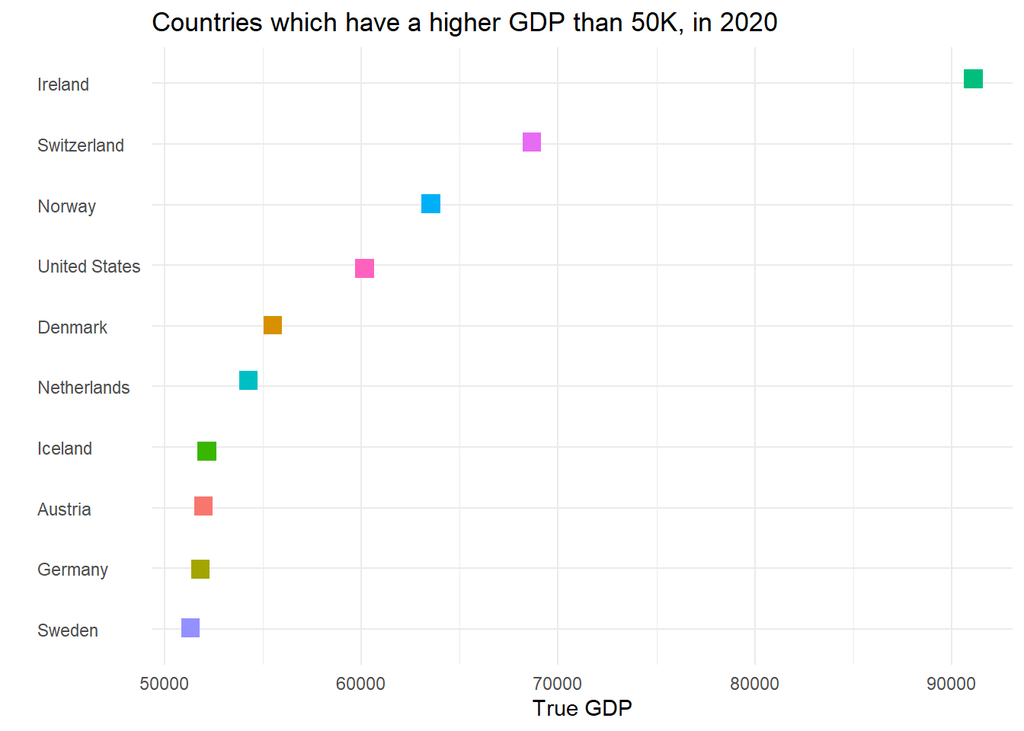

```r
happyindex4 <- happyindex |>
  filter(true_GDP >= 50000, year == 2020)

ggplot(happyindex4, aes(x = true_GDP, y = reorder(country, true_GDP), color = country)) +
  geom_point(position = position_jitterdodge(jitter.width = 0.2, dodge.width = 0.75), size = 4, shape = 15) +
  labs(title = "Countries which have a higher GDP than 50K, in 2020",
       x = "True GDP",
       y = "") +
  theme_minimal() +
  theme(axis.text.y = element_text(hjust = 0)) +
  theme(legend.position = "none")
```

The results reveal a distinct trend, indicating that a majority of **European countries**, excluding *the United States*, exhibited **high GDP per capita**, surpassing the $50,000 value.

## The Correlation Matrix of the Happiness Index Data Set

This illustration delves into the correlation matrix of the Happiness Index data set, providing a comprehensive exploration of the interrelationships between various factors contributing to overall well-being, offering valuable insights into the intricate web of variables influencing happiness scores.

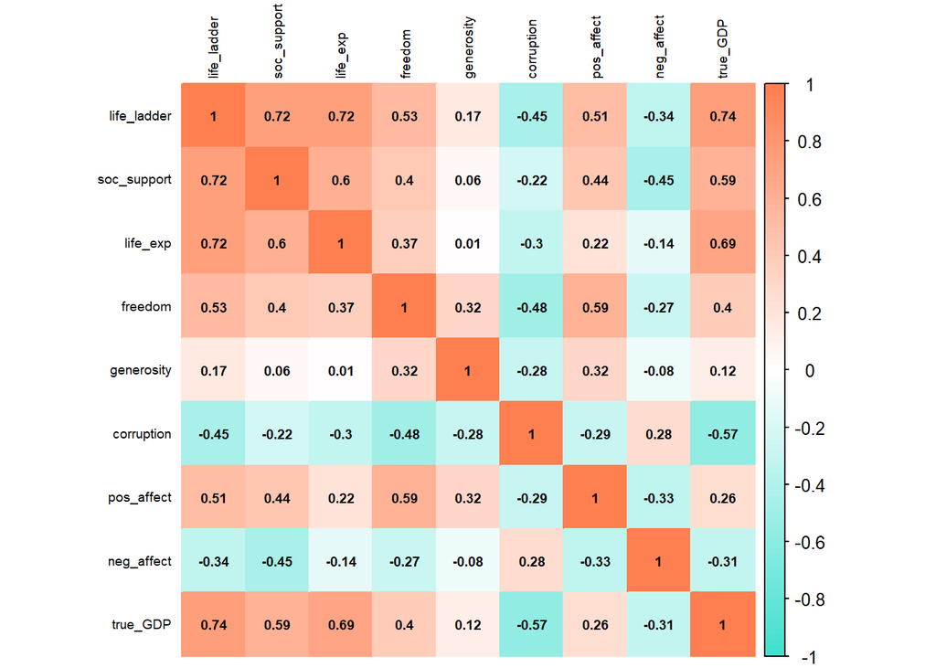

```r
#Creating the correlation matrix only with the numerical variables
happyindex |>
  select(-log_GDP, -year, -country) |> # take out the non-numeric variables
  cor(use = "pairwise.complete.obs")  |> #it omits any pairs of observations where one or both values are missing
  corrplot(method = "color", addCoef.col = "black", tl.col = "black", number.cex = 0.6, tl.cex = 0.6,
           col = colorRampPalette(c("turquoise", "white", "coral"))(100))
```

The variables related to affect, such as positive affect and negative affect, show moderate correlations with other factors. **Positive affect has a positive correlation with life ladder, social support, life expectancy, and freedom, suggesting that higher positive affect is associated with higher well-being indicators.** On the other hand, **negative affect has a negative correlation with these factors, indicating that higher negative affect is associated with lower well-being.**

**True GDP exhibits a positive correlation with life ladder, social support, and life expectancy**, suggesting that **higher economic performance is associated with higher levels of well-being**. Additionally, freedom and generosity show positive correlations with several well-being indicators.

In summary, the correlation matrix provides a comprehensive overview of the relationships between variables in the Happiness Index data set, offering valuable insights into the complex interplay of factors influencing overall well-being.

## Principal Component Analysis

It firstly visualizes **the importance of variables in the first four principal components (PC1 to PC4)** through a bar plot, where each bar represents the contribution of a variable to a principal component.

Secondly, the code calculates and plots **the explained variance for the eight principal components**, providing insights into the proportion of overall variance captured by each component.

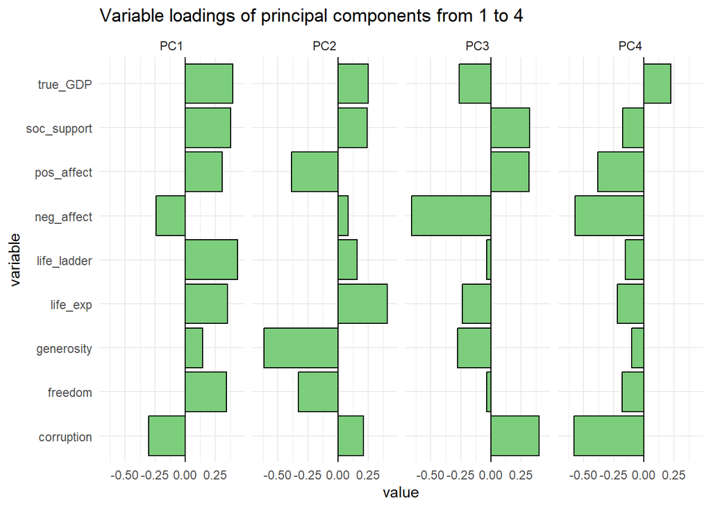

```r
#Creating a new dataframe while removing the non-numerical variables and two other variables that are not needed, in order to center and to scale the data
PCA <- happyindex |>
  select(-country, -year, -log_GDP) |>
  prcomp(scale = TRUE, center = TRUE)

#visualizing the variable loading from PC1 to PC4
PCA$rotation |> as_tibble(rownames = "variable") |>
  pivot_longer(starts_with("PC"), names_to = "PC", values_to = "value") |>
  filter(PC %in% c("PC1", "PC2", "PC3", "PC4")) |>
  ggplot(aes(value, variable)) +
  geom_col(fill = "palegreen3", color = "black") +
  labs(title = "Variable loadings of principal components from 1 to 4") +
  geom_vline(xintercept = 0) +
  facet_wrap(~PC, nrow = 1) +
  theme_minimal()
```

From the first visualization, we can see that the first principal component represents the group of countries who have a high GDP, high values of the positive variables such as life_ladder, soc_support, pos_affect, life_exp, generosity, freedom, and low values in the negative variables like neg_affect and corruption. This group could be seen as **the group of countries which are rich and also have a happy population overall.**

The second principal component, represents the group of countries who have a high GDP and life_exp, but also high corruption and not so happy population (not very high life_ladder, low pos_affect, low generosity and low freedom), that’s why this group could be called as **the “Grumpy” group of the countries.**

The third principal component, represents the group of countries with the low value of true_GDP, life_ladder, life_exp, and neg_affect. This group has high value of the corruption variable, which explains that this group represents **the countries with overall bad economic situation.**

The forth principal component represents the group of unhappy countries with high value of true_GDP and non distinct opinions about the positive and negative variables. It has low neg_affect and low corruption, but then also low pos_affect, which could mean that **there is a diversity among the happiness score for those countries.**

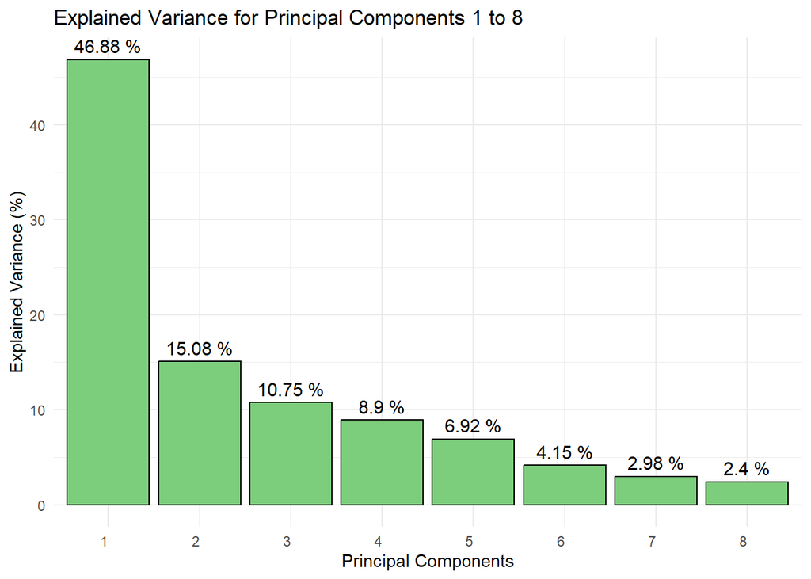

```r
standard_deviations <- PCA$sdev

explained_variance <- (standard_deviations^2) / sum(standard_deviations^2)

data <- data.frame(PC = 1:8, Standard_Deviation = standard_deviations[1:8], Explained_Variance = explained_variance[1:8] * 100)

#Visualizing the explained variance of each principal component
ggplot(data, aes(x = factor(PC), y = Explained_Variance)) +
  geom_bar(stat = "identity", fill = "palegreen3", color = "black") +
  geom_text(aes(label = paste(round(Explained_Variance, 2), "%")), vjust = -0.5, size = 4) +
  labs(title = "Explained Variance for Principal Components 1 to 8",
       x = "Principal Components",
       y = "Explained Variance (%)") +
  theme_minimal() +
  theme(axis.text.x = element_text(hjust = 1))
```

In the second visualization we can see that **the first principal component represents the 46.88% of the explained variance in the data set**, whereas the other principal components explain less than 20% of the variance in the data set. In order to properly explain the variance in the Happy Index data set, we need to take into consideration the first six principal components, which sum up to 92.68% of the explained variance.

### Visualization of the Principal Components by regions

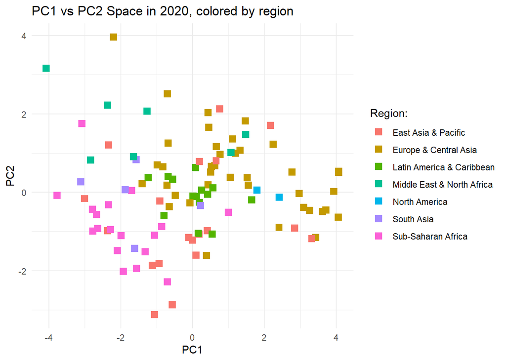

```r
#The same idea has been followed here as for the above chunk, but here we are only interested in the year 2020
happyindex5 <- happyindex |>
  left_join(WDI, by = c("country" = "Country.Name"))


happyindex5 <- happyindex5 |>
  mutate(
    region = if_else(is.na(region), "East Asia & Pacific", region),
  ) |>
  filter(year == 2020)


PCA2 <- happyindex5 |>
  select(-country, -year, -log_GDP, -life_ladder, -region) |>
  prcomp(scale = TRUE, center = TRUE)


pca_df3 <- data.frame(
  PC1 = PCA2$x[, 1],
  PC2 = PCA2$x[, 2],
  region = happyindex5$region,
  country = happyindex5$country
)

#Visualizing the PC1 vs PC2 Space of all the regions in the year 2020s
pca_df3 |>
  ggplot(aes(x = PC1, y = PC2, color = region)) +
  geom_point(size = 3, shape = 15) +
  labs(title = "PC1 vs PC2 Space in 2020, colored by region",
       x = "PC1",
       y = "PC2",
       color = "Region:") +
  theme_minimal()
```

From this visualization, we can see that the similarities between regions and their countries based on their distribution.

Firstly, countries in the regions of **South Asia**, **Sub-Sahaharan Africa**, and **East Asia & Pacific** generally have a negative PC1 and PC2 which means that those countries are not very rich, happy and either grumpy.

Secondly, countries in the regions of **Europe & Central Asia** have positive values for the PC1 and PC2 which means that they are happy and rich countries, however, some of these countries are also Grumpy (level of generosity and pos_affect is low).

As for the **North America** countries, which are Canada and USA, they have a high PC1, which means these countries are rich and also happy.

As for the countries of **Middle East & North Africa** region, most of them have a negative PC1 and positive PC2, which means that these countries are not rich and happy and also they are grumpy. A few of these countries, which are probably the countries from the Middle East region, have a positive PC1 and positive PC2, indicating that those countries are rich and Grumpy (similar to a typical Europe & Central Asia country).

**When comparing the World Map of Happy Index Score and this PCA Visualization Map, we can see that there is a connection between these two visualizations**, because *the countries of America, Europe and Australia are colored as happy countries* whereas *the countries of Africa and Asia are not quite happy* according to the World Map, which were the same insights we got from the PCA Visualization of Countries Map.

# Can the happiness score be forecasted based on the indicators in the happiness index data set?

The primary inquiry driving our investigation is simple: **Is it possible to predict the happiness score based on the indicators in the Happiness Index data set?** This inquiry delves into the realm of predictive modeling, where factors such as GDP, social support, and positive affect serve as the fundamental components of our analytical exploration. The predictive models we have developed, including the **Traditional Model, Logarithmic Transformation Model, and Principal Component Analysis Model**, serve as our current tools, each specifically tailored to reveal distinct insights within the vast amount of data. Each of these models employs Linear Regression. However, we then opt to examine the altered data set using logarithmic transformation. Additionally, we attempt to construct another model by centering and scaling the data. Our objective is *to utilize these models to understand and predict the constantly changing satisfaction levels based on the Happy Index Data Set.*

```r
# Calculate R-squared for each model on the training data
rsq_TM <- rsq(as.data.frame(cbind(train_data$life_ladder, TM_ols_fit$fit$fit$fit$fitted.values)), V1, V2)
rsq_TMln <- rsq(as.data.frame(cbind(train_data$log_life_ladder, TMln_ols_fit$fit$fit$fit$fitted.values)), V1, V2)
rsq_PCA <- rsq(as.data.frame(cbind(train_data$life_ladder, PCA_ols_fit$fit$fit$fit$fitted.values)), V1, V2)

# Add R-squared and the train and the test RMSEs values to the Results table
Results <- tibble(Models = c("TM", "TMln", "PCA"),
                  R_squared = c(rsq_TM$.estimate, rsq_TMln$.estimate, rsq_PCA$.estimate),
                  RMSEtrain = c(sqrt(mean((TM_ols_fit$fit$fit$fit$fitted.values - train_data$life_ladder)^2)),
                                sqrt(mean((exp(TMln_ols_fit$fit$fit$fit$fitted.values) - train_data$life_ladder)^2)),
                                sqrt(mean((PCA_ols_fit$fit$fit$fit$fitted.values - train_data$life_ladder)^2))),
                  RMSEtest = c(sqrt(mean((unlist(predict(TM_ols_fit, test_data)) - test_data$life_ladder)^2)),
                               sqrt(mean((exp(unlist(predict(TMln_ols_fit, test_data))) - test_data$life_ladder)^2)),
                               sqrt(mean((unlist(predict(PCA_ols_fit, test_data)) - test_data$life_ladder)^2)))
                  )


Results_table <- kable(Results, "html") |>
  kable_styling()

#Show the table in the html report
Results_table
```

| Models | R_squared | RMSEtrain | RMSEtest |
| --- | --- | --- | --- |
| TM | 0.7700221 | 0.5467885 | 0.5610792 |
| TMln | 0.7477771 | 0.5285839 | 0.5396441 |
| PCA | 0.7686398 | 0.5484292 | 0.5720801 |

Now, let us evaluate the performance of these models and determine which one is more effective in predicting the happy index score using the other indicators available in the dataset.

*Traditional Model (TM):*

The Traditional Model, considering variables like GDP, freedom, social support, positive affect, and life expectancy, unfolds a tale of happiness. It narrates that around 77% of the variation in life ladder scores can be clarified by these factors. When it takes on the role of predictor, it’s pretty close, with an average error of about 0.55 units, providing a solid grasp of the overall happiness landscape.

*Transformed Model with Logarithmic Transformation (TMln):*

The TMln Model takes a creative twist by transforming the data using logarithms, including the same variables as used in the traditional model, like GDP, freedom, social support, positive affect, and life expectancy. This adjustment still paints a vivid picture, explaining about 74.8% of the nuanced happiness story. In terms of prediction, it has a lower error on both the training and test sets, hinting that this transformation brings us a step closer to a clearer understanding.

*Transformed Model with Principal Component Analysis (PCA):*

The PCA Model employs a sophisticated approach, distilling complex relationships into key components, considering variables like GDP, freedom, social support, positive affect, life expectancy, generosity, and corruption. It captures about 76.9% of the intricate dance of variables affecting happiness. When it ventures into predictions, it’s not far off, maintaining an average error of approximately 0.55 units on the training set and 0.57 units on the test set.

To summarize our predictive journey, the Traditional Model (with an impressive R-squared of 77%) effectively reveals the complex relationship between happiness scores and important variables such as GDP, freedom, social support, positive affect, and life expectancy. This model provides valuable insights, attributing 77% of the variance in life ladder scores to these pivotal factors.

The Logarithmic Transformation Model, however, adds complexity to the story. This model shows better RMSE on the test and training data, even if its R-squared is slightly lower than the classic equivalent. Despite having a lower R-squared, this contradiction demonstrates that the Logarithmic Transformation Model is strong in capturing the essence of happiness. This model shows that there is a complex interaction of elements that affect happiness scores, and it is the most accurate forecasting model currently available.

# Do the cultural, economic, and social features in the happiness index data set align with how happy respondents observed in the European Social Survey Data Set are?

In this segment of our analysis, we embark on an exploration of the connection between Happiness Index scores and the subjective well-being of European citizens, as indicated by the European Social Survey. Our aim is to recognize the disparities between life ladder scores in the Happiness Index and the “how happy” variable in the ESS.

As a first step in our analysis, we look at how happiness levels are spread out across Europe. Using the Probability Mass Function (PMF) and Cumulative Distribution Function (CDF), we show which happiness scores are most common and how people’s happiness is spread out in Europe as a whole.

This basic step is very important for understanding how these data sets are similar. It serves as an exploration of the intricate interplay between official happiness indices and the authentic sentiments of individuals throughout Europe.

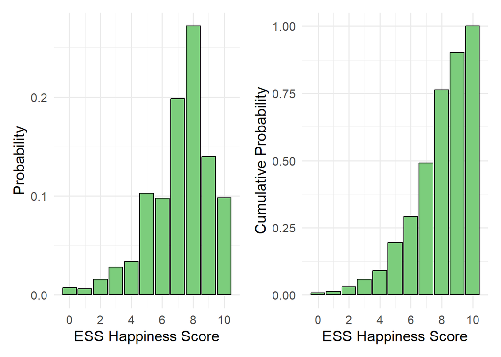

```r
# Creating Probability Mass Function (PMF) for ESS happiness scores
eu <- ess |>
  select(ess_how_happy) |>
  count(ess_how_happy) |>
  mutate(prob = n/sum(n))

# Creating Probability Mass Function (PMF) Plot
eu_mass <- eu |>
  ggplot(aes(ess_how_happy, prob)) +
  geom_col(fill = "palegreen3", color = "black") +
  theme_minimal(base_size = 15) +
  labs(y = "Probability",
       x = "ESS Happiness Score") +
  scale_x_continuous(breaks = seq(0, 10, 2))

# Creating Cumulative Distribution Function (CDF) for ESS happiness scores
eu_distr <- eu |>
  mutate(cumprob = cumsum(prob)) |>
  ggplot(aes(ess_how_happy, cumprob)) +
  geom_col(fill = "palegreen3", color = "black") +
  labs(y = "Cumulative Probability",
       x = "ESS Happiness Score") +
  theme_minimal(base_size = 15) +
  scale_x_continuous(breaks = seq(0, 10, 2))

# Displaying PMF and CDF side by side
eu_mass + eu_distr
```

## Comparison of the happiness score between the ESS and the Happy Index Data Sets

Now, from the earlier on we know that the European countries in the year of 2020 were performing better at the life ladder of the Happy Index Data Set, where such countries were: Finland, Iceland, Denmark, Switzerland, Netherlands, Sweden, Norway, Austria, and Ireland. Also, here we want to see the comparison between the variable of “how happy are you” in the European Social Survey and the “life ladder” from the Happy Index Data Set.

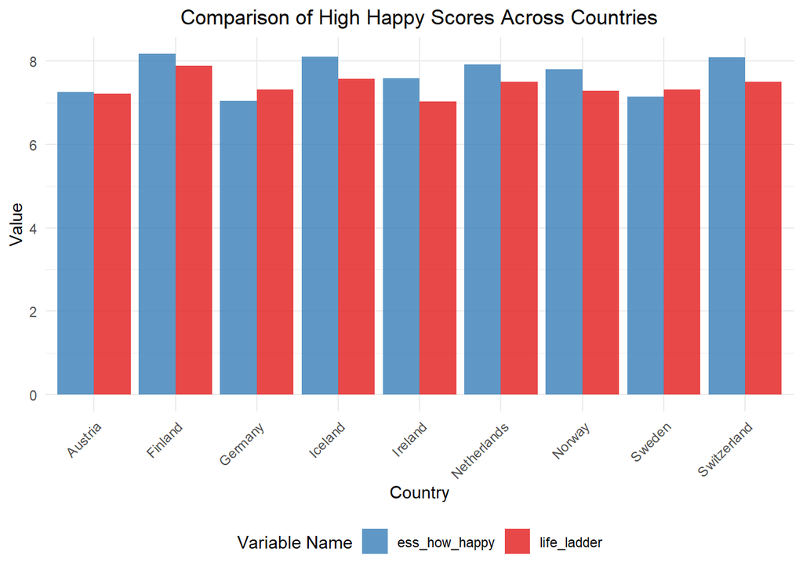

```r
# Creating a filtered and reshaped data frame for specific countries
ess_average_joined_1 <- ess_average_joined |>
  filter(country %in% c("Finland", "Iceland", "Denmark", "Switzerland", "Netherlands", "Sweden", "Germany", "Norway", "Austria", "Ireland")) |>
  pivot_longer(cols = c("ess_how_happy", "life_ladder"),
               names_to = "Type",
               values_to = "Value")

# Plotting the comparison of high happiness scores across countries
ggplot(ess_average_joined_1, aes(x = country, y = Value, fill = Type)) +
  geom_col(position = "dodge", alpha = 0.8) +
  scale_fill_manual(values = c("#377eb8", "#e41a1c"), name = "Variable Name") +
  labs(title = "Comparison of High Happy Scores Across Countries",
       x = "Country",
       y = "Value",
       fill = "") +  # Remove legend title
  theme_minimal() +
  theme(axis.text.x = element_text(angle = 45, hjust = 1)) +
  theme(legend.position = "bottom",
        plot.title = element_text(hjust = 0.5))
```

```r
# Calculating the standard deviation of the difference variable
standard_deviation <- sd(ess_average_joined$difference)
```

As we set out on this analysis, it is important to note that Denmark is absent from the graph. This is due to the fact that Denmark did not take part in the 10th and 10SC rounds of the ESS in the year 2020. In both data sets, our investigation finds a narrative that is constant throughout the majority of European countries, which suggests that there is a nuanced connection between the Happy Index and the ESS metrics.

Despite the fact that we are focusing on nine nations that have performed very well according to the Happy Index Data Set, our interest extends to the European landscape as a whole. In addition to this, we investigate the differences that exist between all of the nations in Europe by analyzing the standard deviation that exists between the two variables, which is a relatively low *0.49*. These variables are the life ladder scores on the Happiness Index and the “how happy” values taken from the ESS.

When interpreted on a scale from 0 to 10, the low standard deviation indicates that the discrepancies between the “life_ladder” values in both data sets are generally minimal and consistent. This finding, which is located within a small range surrounding the mean difference, indicates that the well-being of citizens is being portrayed in a more consistent manner.

Therefore, the low standard deviation (0.49) between Happiness Index and European Social Survey data confirms the alignment of cultural, economic, and social features in the Happiness Index data set with respondents’ happiness levels. This implies a complex but continuous relationship between official happiness indices and subjective well-being across Europe.

# Conclusion

Our investigation into happiness dynamics reveals crucial factors shaping well-being. The Traditional Model effectively explains 77% of happiness variance, underscoring the significance of GDP, social support, positive affect, freedom, and life expectancy.

Predictive modeling introduces nuances, with the Logarithmic Transformation Model outperforming in accuracy, despite a slightly lower R-squared. This model’s adeptness at capturing complex interactions suggests superior forecasting capabilities.

Exploring European Social Survey data indicates alignment with Happy Index Data Set. Despite variations, a low standard deviation implies a nuanced but reliable relationship between official happiness indices and subjective well-being across Europe.

*Limitations and Reliability*

What could be labelled as a limitation in this report is that external factors impacting happiness may not be entirely captured, meaning that other external factors are not present in the data sets and which could have implied the overall happy index score. Moreover another limitation that could be addressed in the European Social Survey is the cultural nuances and survey biases could influence results or the way that respondents have answered.

On the other hand, our findings are reliable within the boundaries of the data and models utilized. The robustness of our analysis relies on the quality and accuracy of the data sets employed, including the Happiness Index Data Set, World Development Indicator Data Set, and European Social Survey Data Set.

In conclusion, our analysis yields valuable insights into global happiness dynamics. While acknowledging limitations, the reliability of our findings within the available data underscores the potential for further exploration and refinement.